# Exploratory Data Analysis of Prosper Loan Data

Yang Yang

Oct 24, 2015

# 1 Introduction

The data used for this analysis is from [Prosper](https://www.prosper.com/about), which is America’s first peer-to peer lending marketplace. It is available to the public (last updated on March 11th, 2014). The data set has 113,937 rows and 81 variables for each loan, including loan amount, borrower rate (or interest rate), current loan status, borrower income, borrower employment status, borrower credit history, and the latest payment information. Techniques learned from the course are applied here to let the data tell some stories about the risk of investment. The goal is to understand how p2p loan works and the performance of a loan, like paid off, or default.

The following features are related to the risk of the loan and I will analyze them in this report:

| Variable | Description |
| --- | --- |
| LoanStatus | The current status of the loan: Cancelled, Chargedoff, Completed, Current, Defaulted, FinalPaymentInProgress, PastDue. The PastDue status will be accompanied by a delinquency bucket. |
| BorrowerRate | The Borrower’s interest rate for the loan |
| DebtToIncomeRatio | The debt to income ratio of the borrower at the time the credit profile was pulled. This value is Null if the debt to income ratio is not available. This value is capped at 10.01 (any debt to income r… |
| StatedMonthlyIncome | The monthly income the borrower stated at the time the listing was created. |
| MonthlyLoanPayment | The scheduled monthly loan payment. |
| EmploymentStatus | The employment status of the borrower at the time they posted the listing. |
| EmploymentStatusDuration | The length in months of the employment status at the time the listing was created. |
| ProsperRating (Alpha) | The Prosper Rating assigned at the time the listing was created between AA - HR. Applicable for loans originated after July 2009. |
| CreditGrade | The Credit rating that was assigned at the time the listing went live. Applicable for listings pre-2009 period and will only be populated for those listings. |
| OpenCreditLines | Number of open credit lines at the time the credit profile was pulled. |
| CurrentDelinquencies | Number of accounts delinquent at the time the credit profile was pulled. |
| DelinquenciesLast7Years | Number of delinquencies in the past 7 years at the time the credit profile was pulled. |
| LoanOriginationDate | The date the loan was originated. |
| LoanOriginalAmount | The origination amount of the loan. |

# 2 Univariate Plots and Analysis

## 2.1 Univariate Plots

### 2.1.1 Data Set Structure Overview

Structure of the data and a quick summary is shown below.

```
## 'data.frame':    113937 obs. of  14 variables:
##  $ LoanStatus              : Factor w/ 12 levels "Cancelled","Chargedoff",..: 3 4 3 4 4 4 4 4 4 4 ...
##  $ BorrowerRate            : num  0.158 0.092 0.275 0.0974 0.2085 ...
##  $ DebtToIncomeRatio       : num  0.17 0.18 0.06 0.15 0.26 0.36 0.27 0.24 0.25 0.25 ...
##  $ StatedMonthlyIncome     : num  3083 6125 2083 2875 9583 ...
##  $ MonthlyLoanPayment      : num  330 319 123 321 564 ...
##  $ EmploymentStatus        : Factor w/ 8 levels "Employed","Full-time",..: 8 1 3 1 1 1 1 1 1 1 ...
##  $ EmploymentStatusDuration: int  2 44 NA 113 44 82 172 103 269 269 ...
##  $ ProsperRating..Alpha.   : Factor w/ 7 levels "AA","A","B","C",..: NA 2 NA 2 5 3 6 4 1 1 ...
##  $ CreditGrade             : Factor w/ 8 levels "A","AA","B","C",..: 4 NA 7 NA NA NA NA NA NA NA ...
##  $ OpenCreditLines         : int  4 14 NA 5 19 17 7 6 16 16 ...
##  $ CurrentDelinquencies    : int  2 0 1 4 0 0 0 0 0 0 ...
##  $ DelinquenciesLast7Years : int  4 0 0 14 0 0 0 0 0 0 ...
##  $ LoanOriginationDate     : Date, format: "2007-09-12" "2014-03-03" ...
##  $ LoanOriginalAmount      : int  9425 10000 3001 10000 15000 15000 3000 10000 10000 10000 ...
```

```
##                  LoanStatus     BorrowerRate    DebtToIncomeRatio
##  Current              :56576   Min.   :0.0000   Min.   : 0.000
##  Completed            :38074   1st Qu.:0.1340   1st Qu.: 0.140
##  Chargedoff           :11992   Median :0.1840   Median : 0.220
##  Defaulted            : 5018   Mean   :0.1928   Mean   : 0.276
##  Past Due (1-15 days) :  806   3rd Qu.:0.2500   3rd Qu.: 0.320
##  Past Due (31-60 days):  363   Max.   :0.4975   Max.   :10.010
##  (Other)              : 1108                    NA's   :8554
##  StatedMonthlyIncome MonthlyLoanPayment      EmploymentStatus
##  Min.   :      0     Min.   :   0.0     Employed     :67322
##  1st Qu.:   3200     1st Qu.: 131.6     Full-time    :26355
##  Median :   4667     Median : 217.7     Self-employed: 6134
##  Mean   :   5608     Mean   : 272.5     Not available: 5347
##  3rd Qu.:   6825     3rd Qu.: 371.6     Other        : 3806
##  Max.   :1750003     Max.   :2251.5     (Other)      : 2718
##                                         NA's         : 2255
##  EmploymentStatusDuration ProsperRating..Alpha.  CreditGrade
##  Min.   :  0.00           C      :18345         C      : 5649
##  1st Qu.: 26.00           B      :15581         D      : 5153
##  Median : 67.00           A      :14551         B      : 4389
##  Mean   : 96.07           D      :14274         AA     : 3509
##  3rd Qu.:137.00           E      : 9795         HR     : 3508
##  Max.   :755.00           (Other):12307         (Other): 6745
##  NA's   :7625             NA's   :29084         NA's   :84984
##  OpenCreditLines CurrentDelinquencies DelinquenciesLast7Years
##  Min.   : 0.00   Min.   : 0.0000      Min.   : 0.000
##  1st Qu.: 6.00   1st Qu.: 0.0000      1st Qu.: 0.000
##  Median : 9.00   Median : 0.0000      Median : 0.000
##  Mean   : 9.26   Mean   : 0.5921      Mean   : 4.155
##  3rd Qu.:12.00   3rd Qu.: 0.0000      3rd Qu.: 3.000
##  Max.   :54.00   Max.   :83.0000      Max.   :99.000
##  NA's   :7604    NA's   :697          NA's   :990
##  LoanOriginationDate  LoanOriginalAmount
##  Min.   :2005-11-15   Min.   : 1000
##  1st Qu.:2008-10-02   1st Qu.: 4000
##  Median :2012-06-26   Median : 6500
##  Mean   :2011-07-21   Mean   : 8337
##  3rd Qu.:2013-09-18   3rd Qu.:12000
##  Max.   :2014-03-12   Max.   :35000
##
```

### 2.1.2 Loan Status

To get a feeling about the risk of being an investor, loan status is checked first. About 15% of all the loans have status of “charged off”, “default”, or “past due”. And 33% are completed, and 50% is still in the process. The “Past due” is less than 2% which is very impressed. In traditional lending industr , it will be more than 10%. People who applied loans online are totally different from the traditional world.

| Loan Status | Percentage (%) |
| --- | --- |
| Cancelled | 0.0043884 |
| Chargedoff | 10.5251148 |
| Completed | 33.4167127 |
| Current | 49.6555114 |
| Defaulted | 4.4041883 |
| FinalPaymentInProgress | 0.1799240 |
| Past Due (>120 days) | 0.0140428 |
| Past Due (1-15 days) | 0.7074085 |
| Past Due (16-30 days) | 0.2325847 |
| Past Due (31-60 days) | 0.3185971 |
| Past Due (61-90 days) | 0.2747132 |
| Past Due (91-120 days) | 0.2668141 |

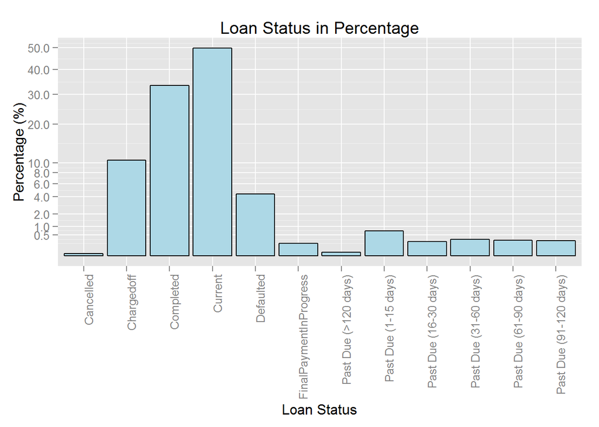

### 2.1.3 Borrower Rate

Borrower rate is slightly skewed to the right. The mean of the borrower rate is 19% which is a slighter higher than the median 18%. The main cause for the right skew is the high percentage of the borrower rate at 32% and 35% which I believe is high risk customer.

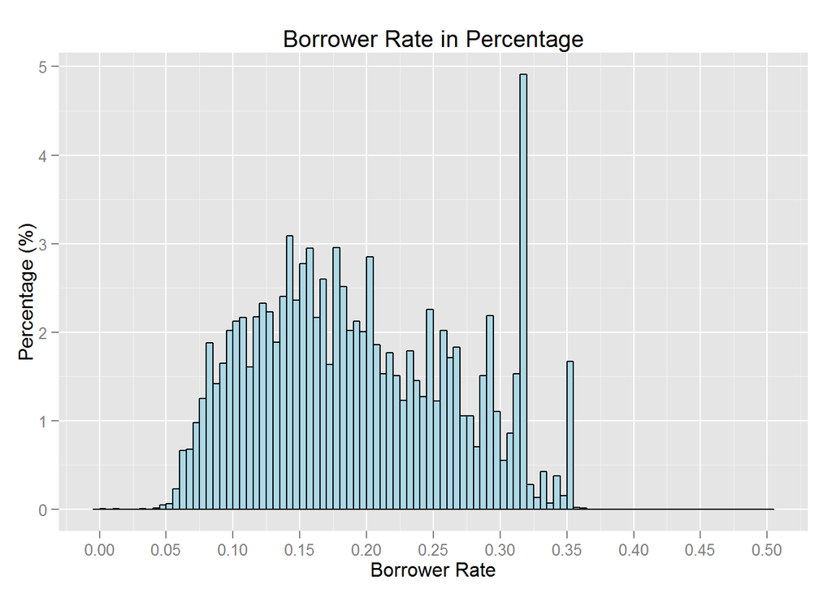

### 2.1.4 Debt to Income Ratio

It’s obvious that most of the borrowers has debt-to-income-ratio less than 1, otherwise they could not afford their loans. Weird cases happend probably they have co-applicant. The avg debt-to-income-ratio is around 30% which is aligned with the other finacial companies. It’s a rule of thumb that home mortgage will be 4 times of one’s income. You can see from the summary table that 75% of the borrowers has the ratio less than 32%. Note: In the plot, data with debt-to-income-ratio larger than 1 is ignored.

| Debt to income ratio > 1? | Percentage (%) |
| --- | --- |
| FALSE | 99.2418132 |
| TRUE | 0.7581868 |

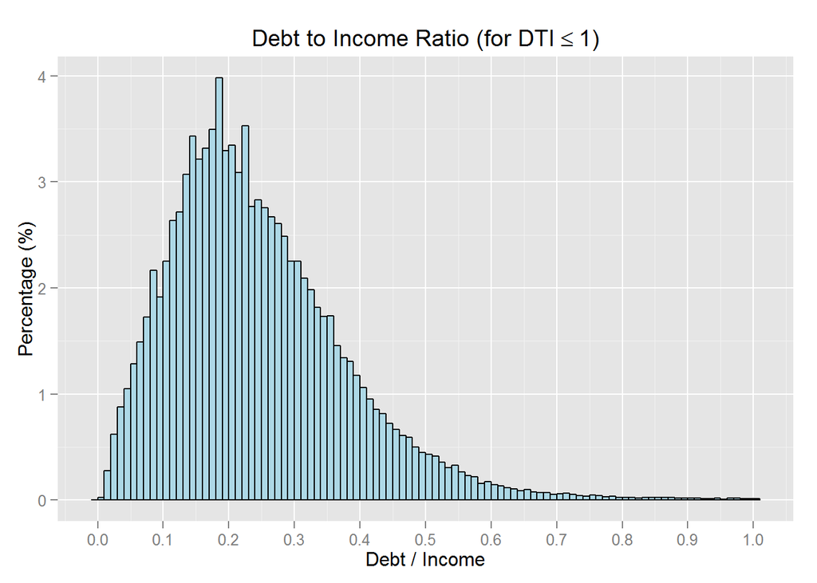

### 2.1.5 Stated Monthly Income

```
##    Min. 1st Qu.  Median    Mean 3rd Qu.    Max.
##       0    3200    4667    5608    6825 1750000
```

99th quantile of the stated monthly income is about $20526.7 which is still high.

```
##       25%       50%       75%       90%       99%     99.5%
##  3200.333  4666.667  6825.000  9750.000 20526.667 25000.000
```

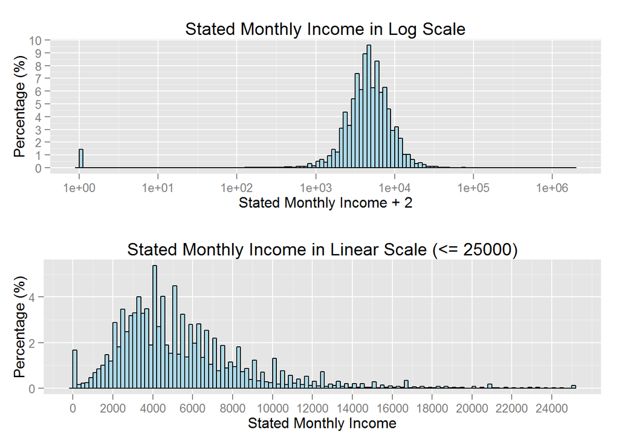

### 2.1.6 Monthly Loan Payment

Median of the monthly loan payment is 217.74; 90th quantile of monthly loan payment is 535.91. The regular loan payment is lower than any regular auto loan/credit card payment. Probably that’s why people go to P2P online lending. Otherwise it will be very costive and time consuming to do it offline in office or in person.

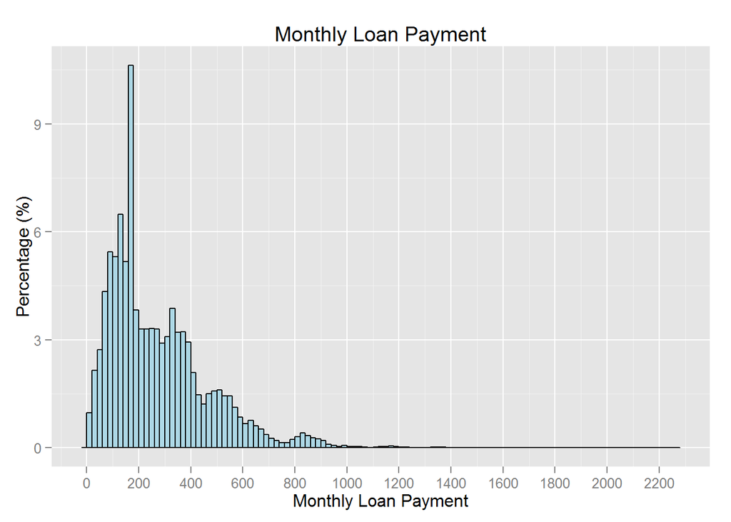

It is also interesting to see how much of the income is used to pay for the loan each month.So a new variable called “MonthlyLoanPaymentToIncomeRatio” was created: $MonthlyLoanPaymentToIncomeRatio = MonthlyLoanPayment / StatedMonthly Income$.

For about 1.5% of the borrowers as shown in the plot below, this ratio is greater than 1, possibly due to incorrect monthly income. This ratio is capped at 1.01; any value greated than 1 is replaced by 1.01. We can see the ratio is right skewed. And it’s not as normalized as the debt to income ratio. Actually if we add the new monthly loan payment to the original debt, it will be similar to the debt to income ratio.

```
##        50%        90%        95%        97%
## 0.04962087 0.11283831 0.14442627 0.19409474
```

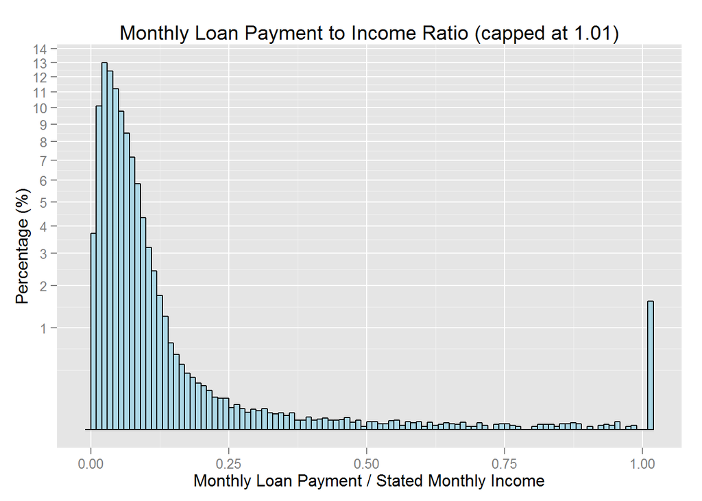

### 2.1.7 Employment Status and Duration

The majority of the borrowers are employed. But it is not clear what the status “Other” means. Besides, it is not clear how much from the category “Employed” is full-time.

| Employment Status | Percentage (%) |
| --- | --- |
| Employed | 60.2800809 |
| Full-time | 23.5982522 |
| Not available | 4.7877008 |
| Not employed | 0.7476585 |
| Other | 3.4078903 |
| Part-time | 0.9741946 |
| Retired | 0.7118426 |
| Self-employed | 5.4923802 |

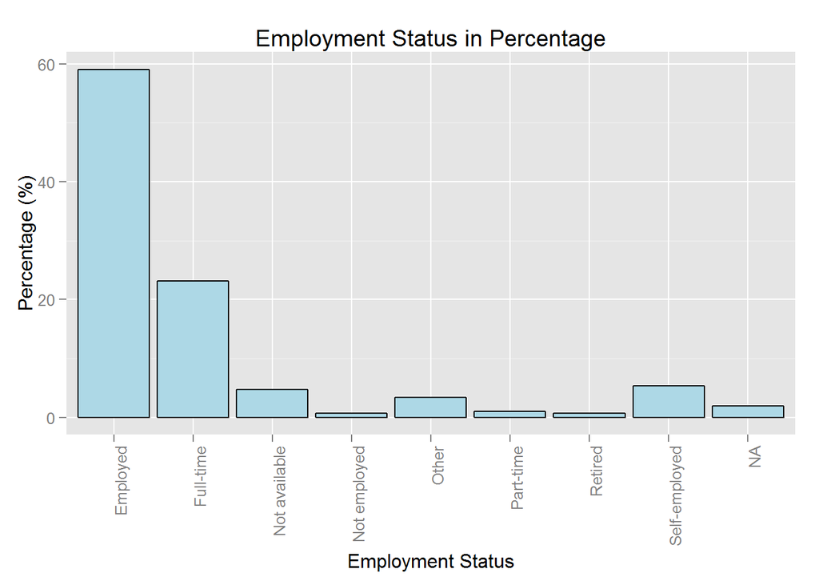

And for the employment status duration, it’s right skewed. It seems like the young workers would like to apply for the P2P online lending.

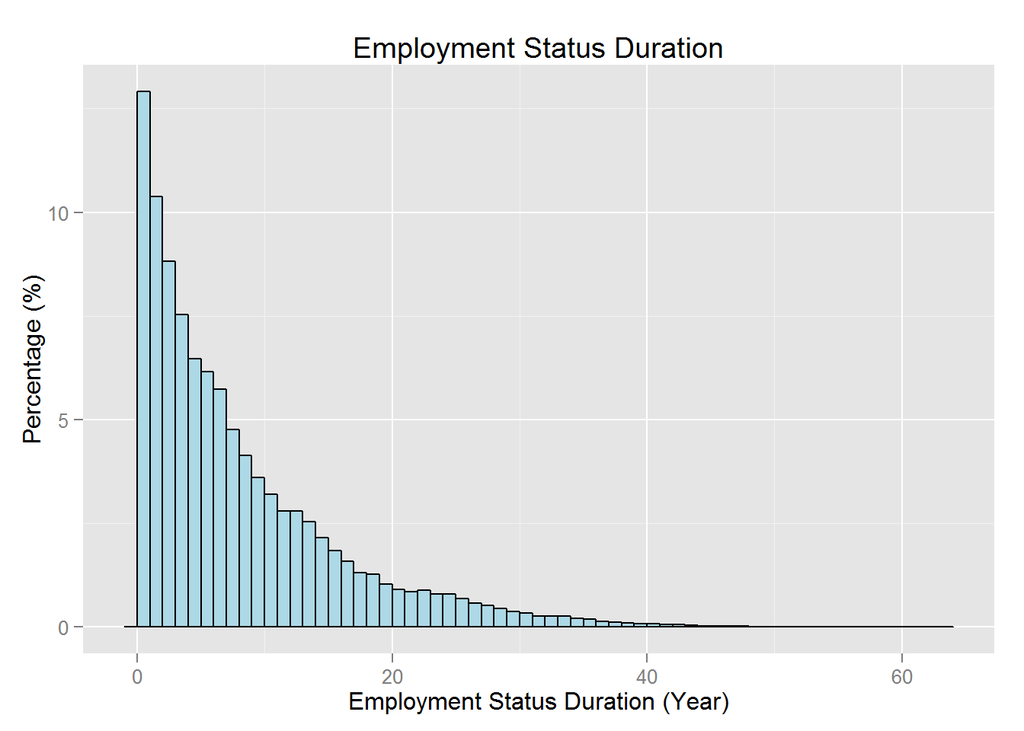

### 2.1.8 Prosper Rating

Prosper was required to suspend its business pending SEC approval from Oct 1 , 2008 to July 13, 2009, known as [Prosper’s Quiet Period](http://www.lendacademy.com/a-look-back-at-the-lending-club-and-prosper-quiet-periods/). After this period, Prosper introduced “[Prosper Rating](https://www.prosper.com/invest/how-to-invest/prosper-ratings/)” to allow potential investors to easily consider a loan application’s level of risk because the rating represents an estimated average annualized loss rate range to the investor. we can see from the following two graphs, that the risk is normal distributed in their loans. You can get some very good borrowe , you also get some pretty bad borrower. But you can earn much more from the bad borrower.

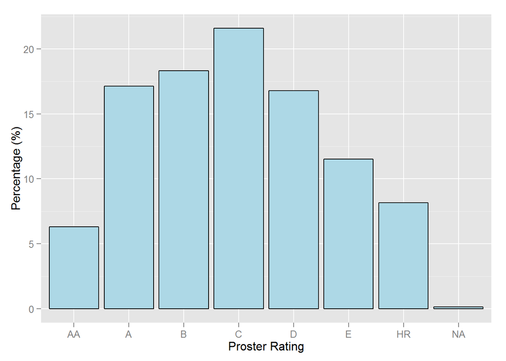

Before July 13, 2009, the so-called “CreditGrade” was assigned when the loan listing went live.

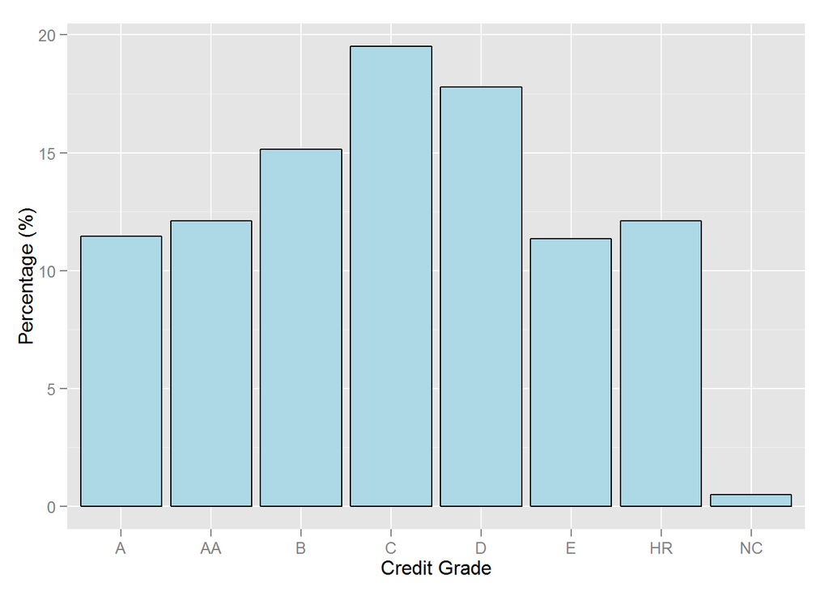

### 2.1.9 Open Credit Lines

It’s also interesting to see how many open credit lines do the borrower have. The avg and median of the open credit lines are both 9 which is reasonable. Though we see some have 40 or 50, probably they abuse the credit lines.

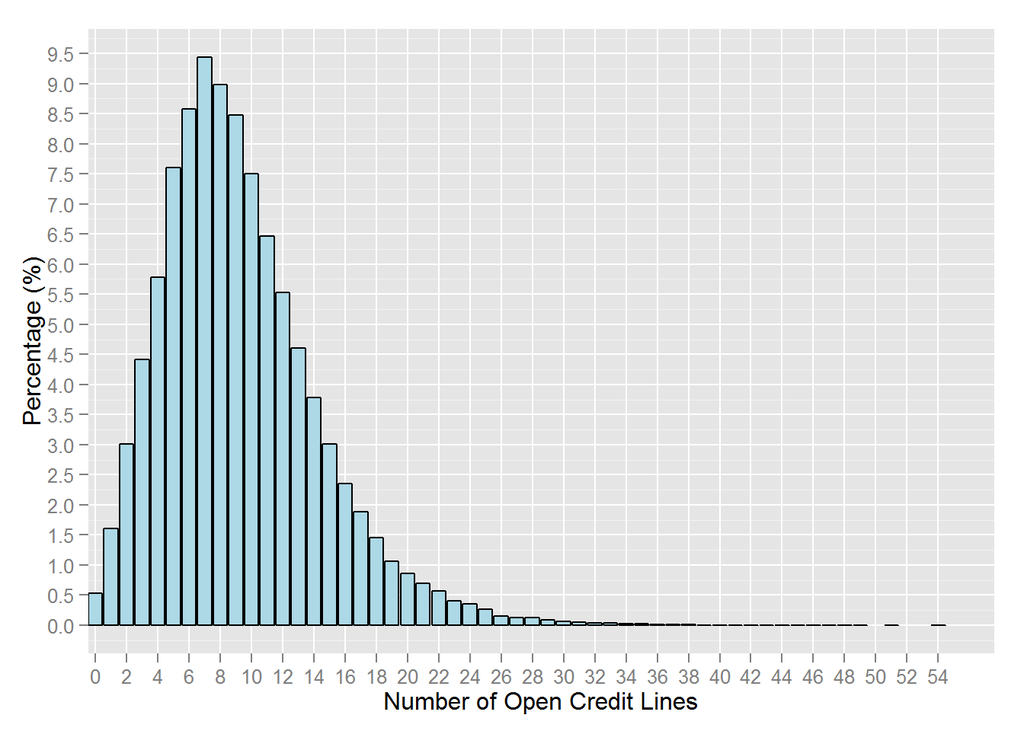

### 2.1.10 Current Delinquencies

As shown below, about 80% of the borrowers don’t have delinquencies; the number of current delinquencies is less than or equal to 10 for 99% of the borrowers. It will be high risky if the borrower already delinquent. And the borrower probably just open a new credit line to cover the other delinquency.

```
## 50% 90% 99%
##   0   2  10
```

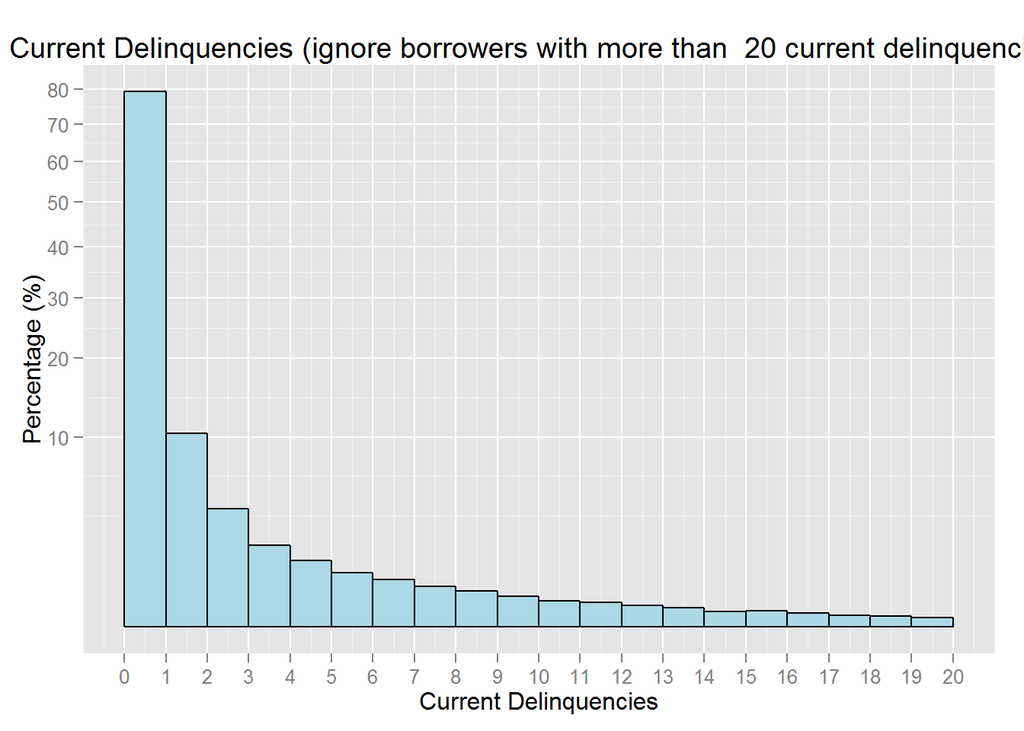

### 2.1.11 Delinquencies in Last 7 Years

Previous borrower behavior would give us an insight if the borrower is good or not. About 70% of them don’t have any delinquency, and 95% of the borrowers have less than 24 delinquencies in the past 7 years. It is unclear there is a spike at 99 in the plot below; but the percentage is pretty low, which is about 0.0965446%.

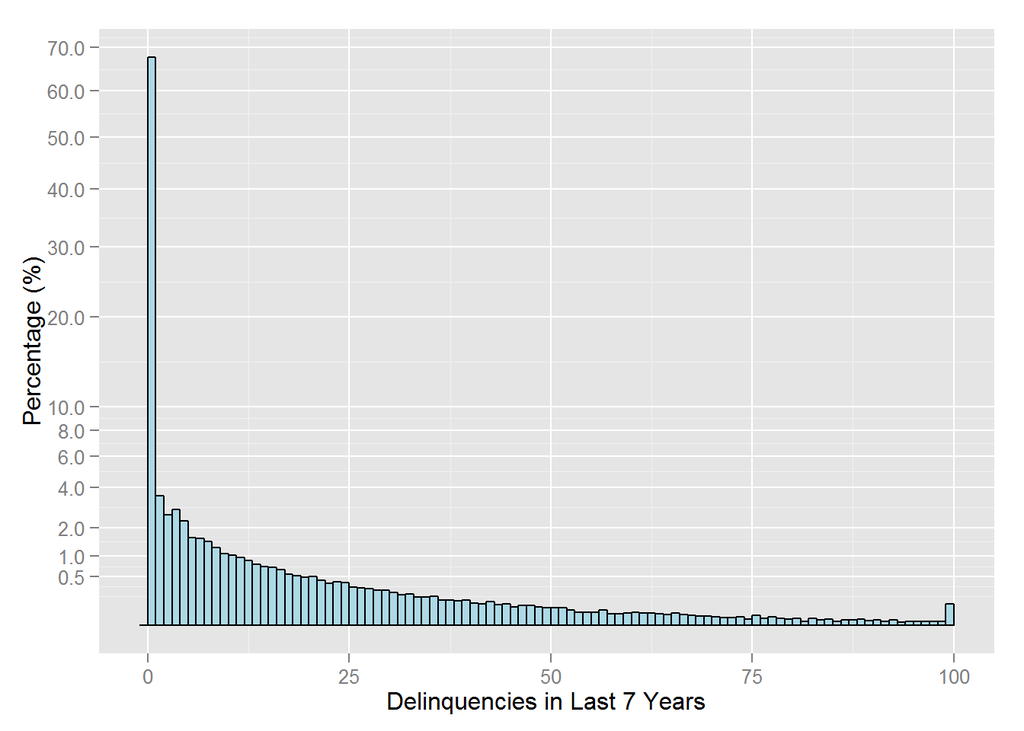

## 2.2 Univariate Analysis

### 2.2.1 What is/are the main feature(s) of interest in your dataset?

As we all know, the P2P online lending is to help people to payoff their debts more convient and give both the borrower and the lender the opportunity to choose the best for them which is totally different from the traditional lending industry. For the investors, they will use the Prosper Rating to determine if they fund the loan or not, and if the loan will be default or not. For the borrowers, the Prosper Rating is critial to their application, whether they will get the loan or not. So the main features will be their Prosper Rating and loan status.

### 2.2.2 What other features in the dataset do you think will help support your investigation into your feature(s) of interest?

The Prosper Rating is the key in the prosper lending business. I would like to explore all the other credit related variables to see how they related to the prosper rating and the loan status. I picked employment status, employment status duration, stated monthly income, current delinquencies, debt to income ratio etc. Other information such as EmploymentStatusVerifiable“,”AmountDelinquent" may also be useful.

### 2.2.3 Did you create any new variables from existing variables in the dataset?

I created three variables for the analysis.

The current loan status has too many levels, then it is simiplified into 3 factor levels: 1. Good Loan: Completed or Final Payment in Progress; 2. Bad Loan: Charged-off, Default, Cancelled or Past Due; 3. Current: Current,Since loan with status “Cancelled” or “Past Due” are only a small portion of the dataset. Including them in the “Bad Loan” category should not change the analysis results.

Besides, I also converted LoanOriginationDate as Date object, which will facilitate analysis in the following sections.

I also created a variable of the ratio of MonthlyLoanPayment to Stated Monthly Income. The ratio will tell us the borrower’s ability to pay off the debt.

### 2.2.4 Of the features you investigated, were there any unusual distributions? Did you perform any operations on the data to tidy, adjust, or change the form of the data? If so, why did you do this?

The disbribution of StatedMonthlyIncome is unusaual. The tail is very long. These numbers are probably entered by the borrowers and probably contains incorrect information. In the following analysis, StatedMonthlyIncome larger than 99th quantile are ignored.

Debt to Income ratio has the same issue. For people who is already utilized their income for the debt, it’s impossible to pay back the new debt. I will be some capping and flooring for the other data as well.

# 3 Bivariate Plots and Analysis

## 3.1 Bivariate Plot

### 3.1.1 Prosper Rating and Loan Status

As mentioned above, loan status is simplified as “Good Loan”, “Bad Loan” and Current“. Prosper rating clearly shows a strong relationship with the loan status. Lower rating indicates a higher percentage of bad loans.

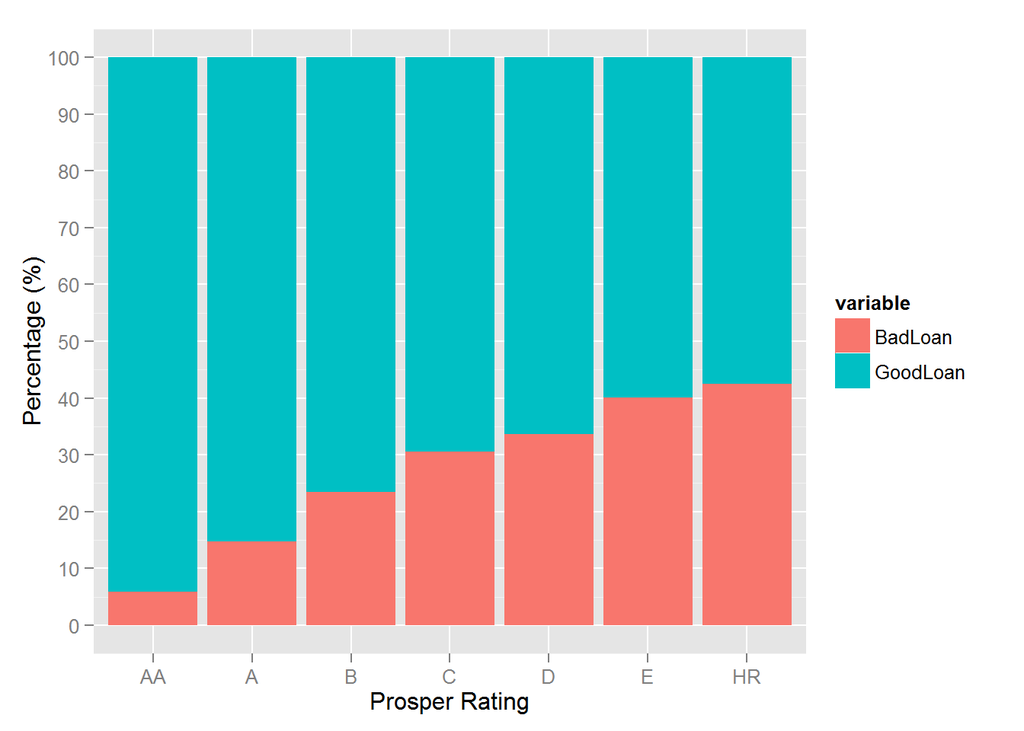

### 3.1.2 Relationship between Loan Status and Debt-to-Income-Ratio, Monthly Income, Open Credit Lines and Current Delinquencies

“Good Loan” shows a lower median debt to income ratio; interestingly, the “Current” loan shows a higher median of debt to income ration than both bad and good loans. I guess that the “Good Loan” and “Bad Loan” are several years older, and the loan size is smaller than the current ones. And more people are moving to get loans from the online lender, the borrowers will definitely be different from the old population, probably shift to more wealthy people.

As expected, “Good Loan” shows a higher median income. “Current” loan shows a higher median income than both good and bad loans. The trend is similar for open credit lines.

The portion of borrowers within the “Bad Loan” group that have current delinquencies is higher than the other two groups.

As for the duration of employment status, there is no significant difference between bad and good loan.

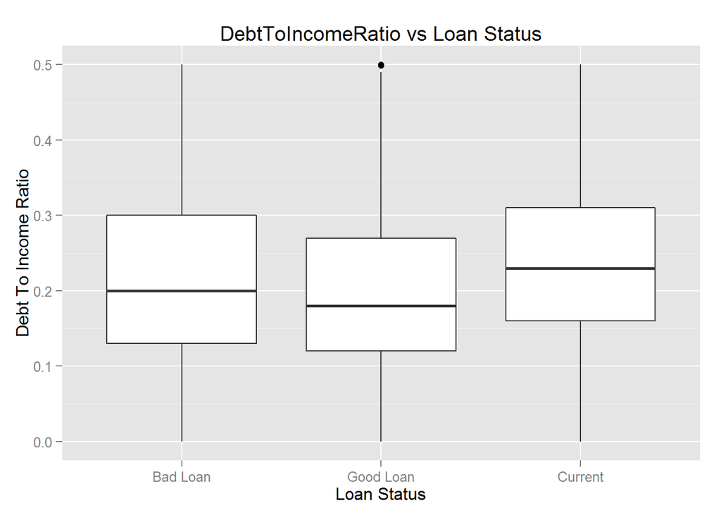

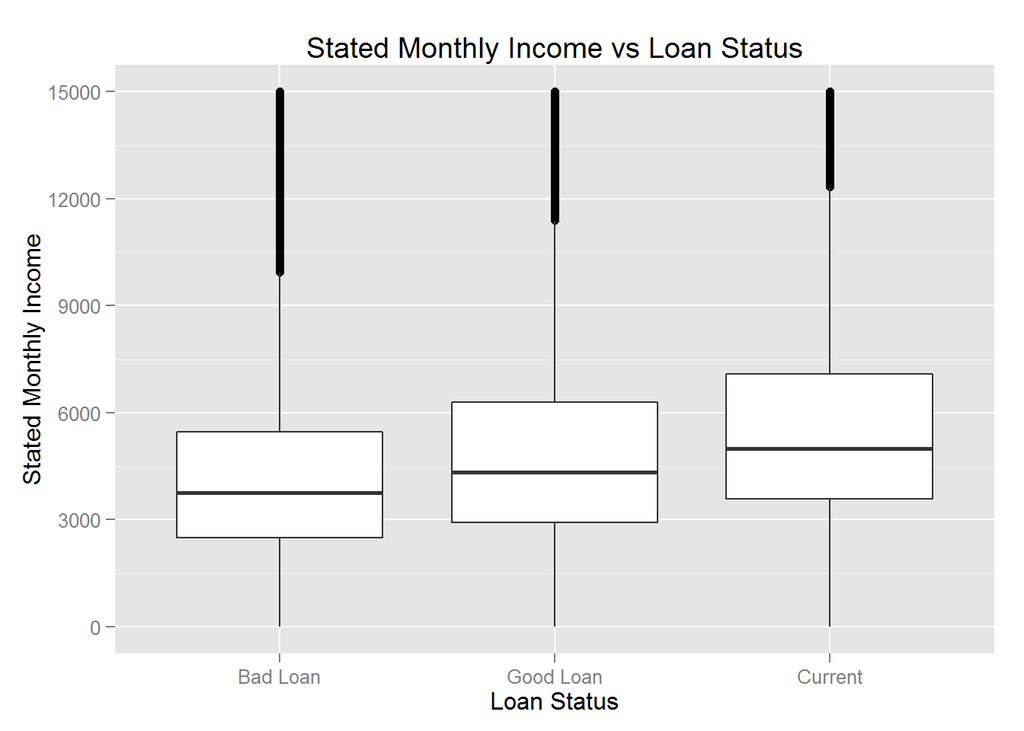

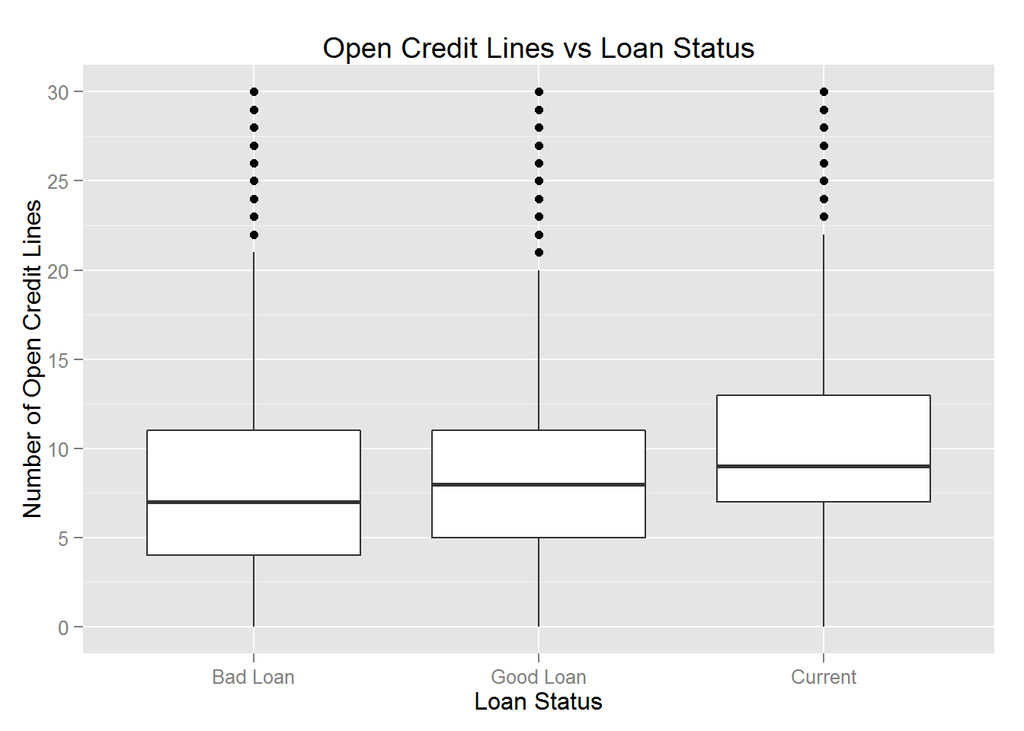

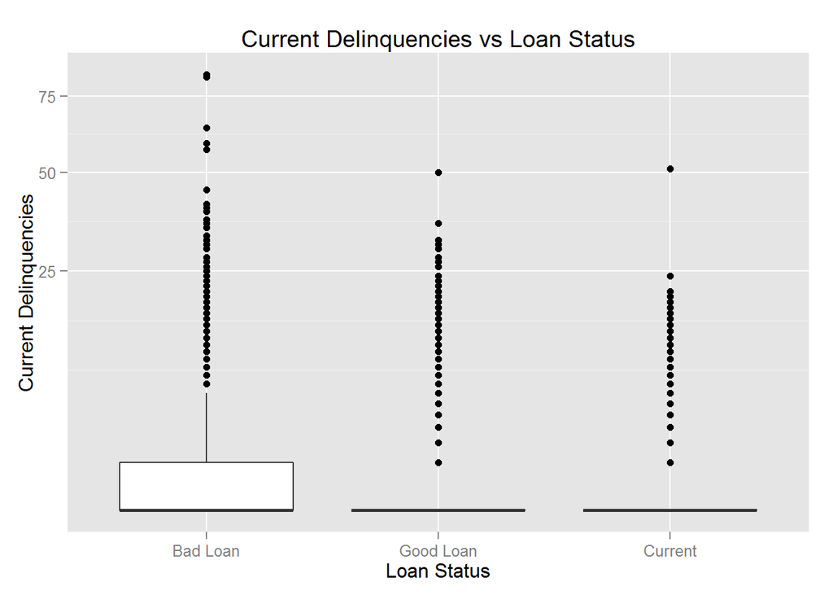

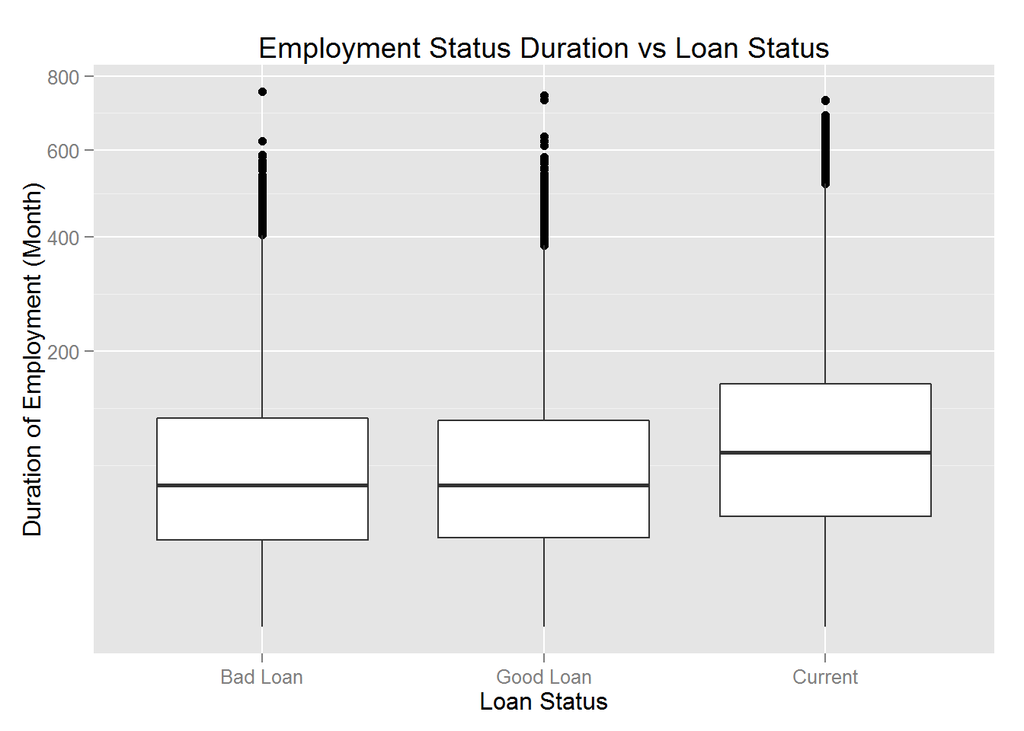

### 3.1.3 Prosper Rating and DebtToIncomeRatio

Smaller debt to income ratio tends to have better Prosper Rating. But the debt to income ratio seems to be stable in the other credit groups: C, D, E and HR. It’s probably because the ratio will be capped in the Prosper Rating decision. And we can see that more bad Prosper Rating borrowers in the loan portofilo. I think online lending is more attractive to the bad rating borrower since they are hard to get the loan and good borrow rate from the traditional finance industry.

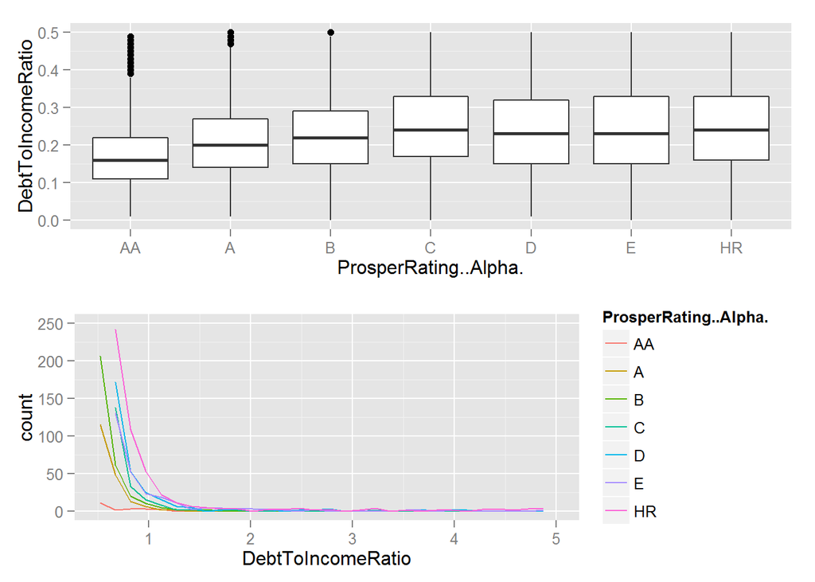

### 3.1.4 Expected Return Increases with Risk Level

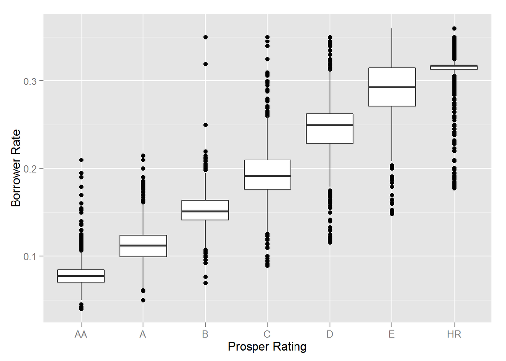

### 3.1.5 Loan Data Variation through Time

Debt-to-income-ratio, stated monthly income and loan original amount all increase over the time. There is a drop from Oct, 2008 to Jun, 2009 as the result of the economic crisis. But it went up right after that. Probably it’s because that the traditional finance company couldn’t offer more and people are switching to the online lending.

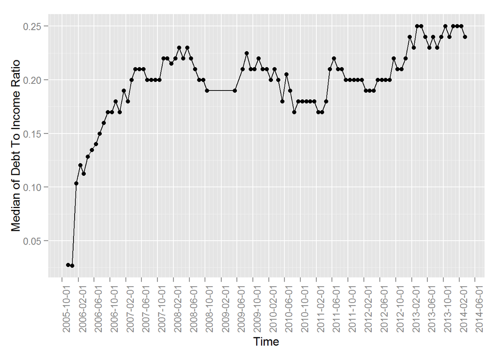

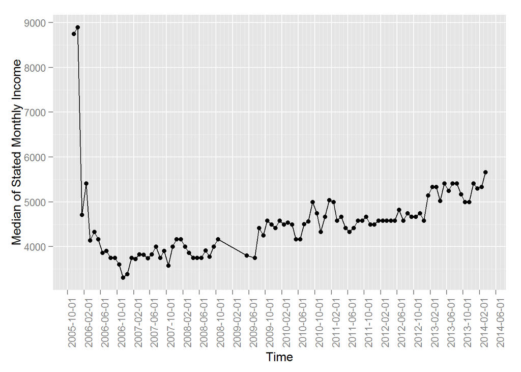

[figure not shown]

### 3.1.6 The relationship between the numeric variables

```
## [1] "BorrowerRate"             "DebtToIncomeRatio"
## [3] "StatedMonthlyIncome"      "MonthlyLoanPayment"
## [5] "EmploymentStatusDuration" "OpenCreditLines"
## [7] "CurrentDelinquencies"     "DelinquenciesLast7Years"
```

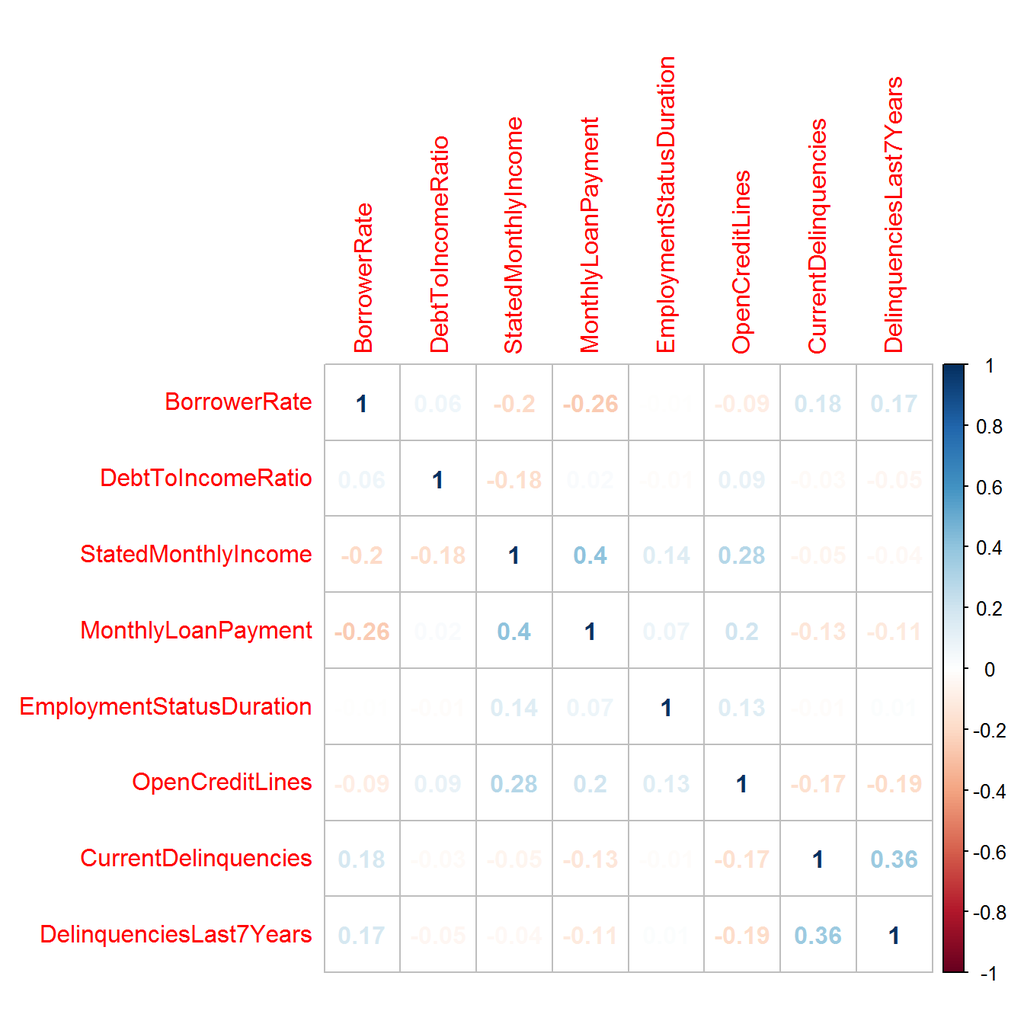

## 3.2 Bivariate Analysis

### 3.2.2 Did you observe any interesting relationships between the other features (not the main feature(s) of interest)?

# 4 Multivariate Plots And Analysis

## 4.1 Multivariate Plots

### 4.1.1 Borrower Rate, Loan Status and Debt to Income Ratio

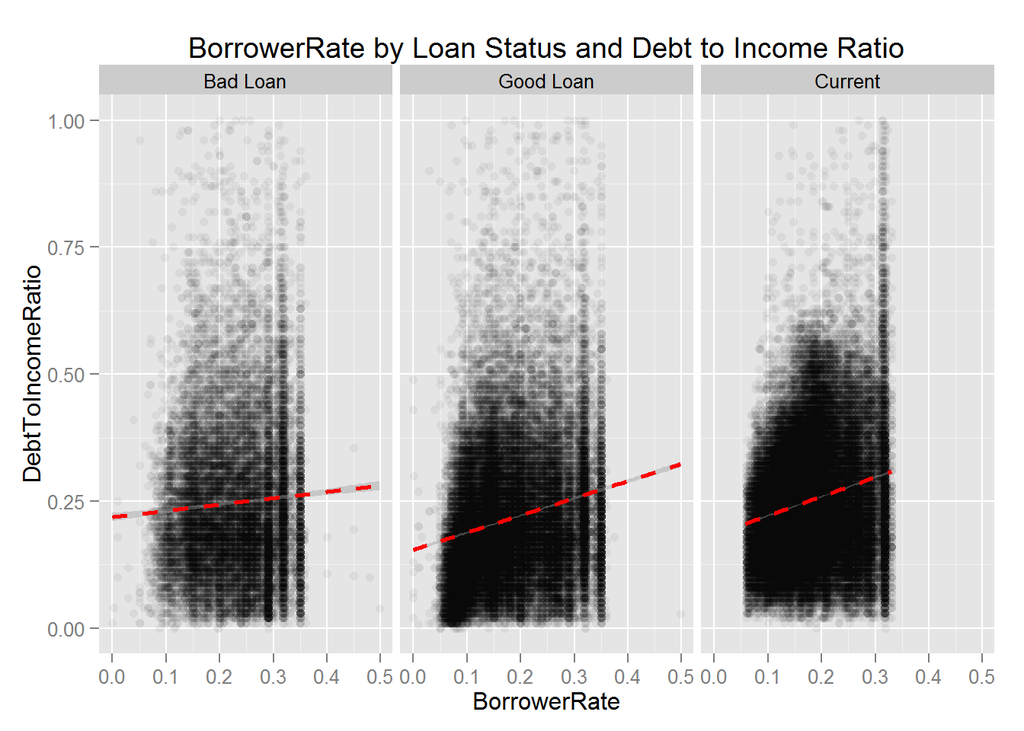

The correlation coefficient between BorrowerRate and DebtToIncomeRatio by 3 different loan status group is shown below:

```
## Source: local data frame [3 x 2]
##
##   LoanStatusGrouped cor(BorrowerRate, DebtToIncomeRatio)
## 1          Bad Loan                          0.004875592
## 2         Good Loan                          0.043341081
## 3           Current                          0.139135462
```

### 4.1.2 BorrowerRate, Delinquencies in Last 7 years and Loan Status

It seems like the delinquencies in last 7 years don’t have a clearly pattern with the current loan status. We can see the number of Delinquecies is well distributed in the whole population, but the extreme high delinquencies will have more bad loans. The borrower Rate seems not correlated with the delinques.

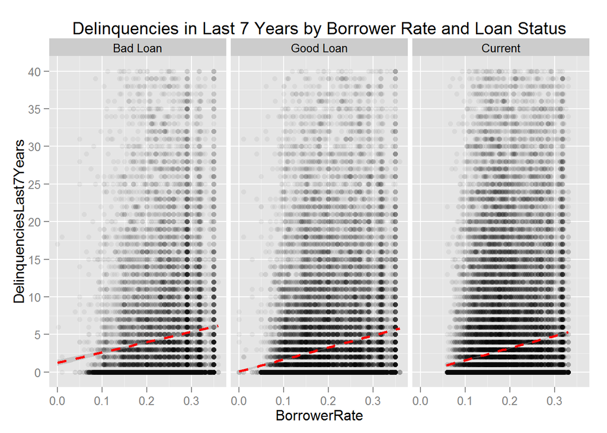

The correlation coefficient between BorrowerRate and DelinquenciesLast7Years by 3 different loan status group is shown below:

```
## Source: local data frame [3 x 2]
##
##   LoanStatusGrouped cor(BorrowerRate, DelinquenciesLast7Y...
## 1          Bad Loan                                0.1171437
## 2         Good Loan                                0.1852691
## 3           Current                                0.1542938
```

### 4.1.3 Borrower Rate, Loan Status and Prosper Rating

Bad Loans are more likely follow into the bad Prosper Rating, especially those don’t have any credit rating. And we can also see that Borrower Rate is higher in the right hand group.

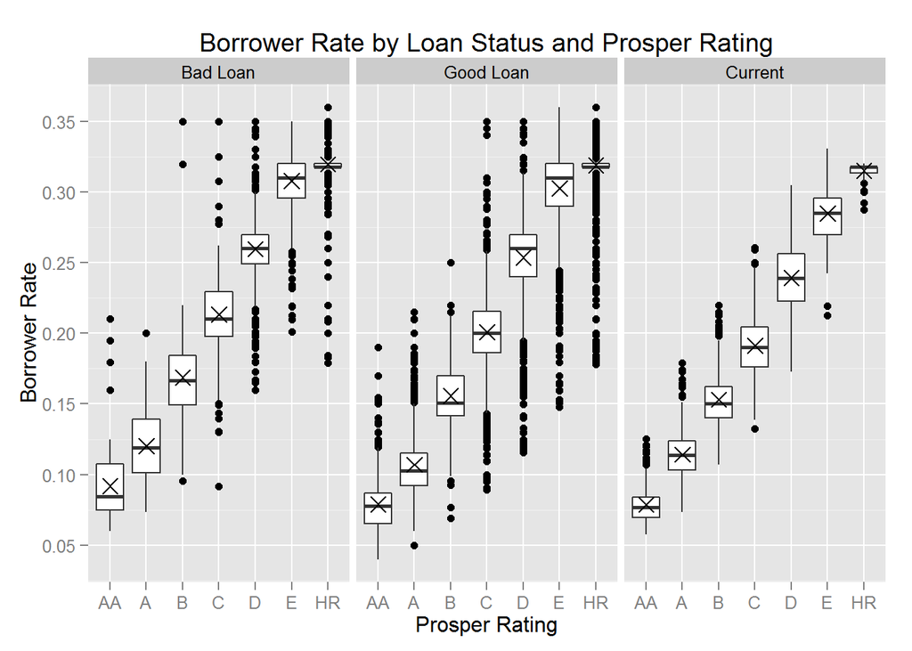

### 4.1.4 Debt to Income Ratio, Loan Status and Prosper Rating

Worse Prosper Rating tends to have more bad loans, and have a much wider debt to income ratio.

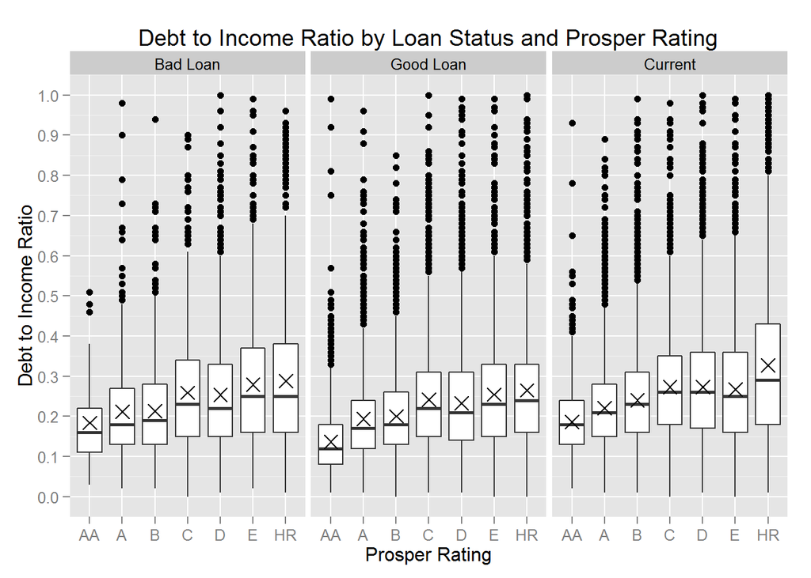

### 4.1.5 Open Credit Line, Loan Status and Prosper Rating

The Open credit line seems not have a strong relationship with the Prosper Rating and the Loan Status. We can not determine borrowers behavior without looking at the “Good” Credit lines. Probably, they have more open credit lines just because of the credit card debt utilization. Or some really good customers may utilize their credit card rewards systerm.

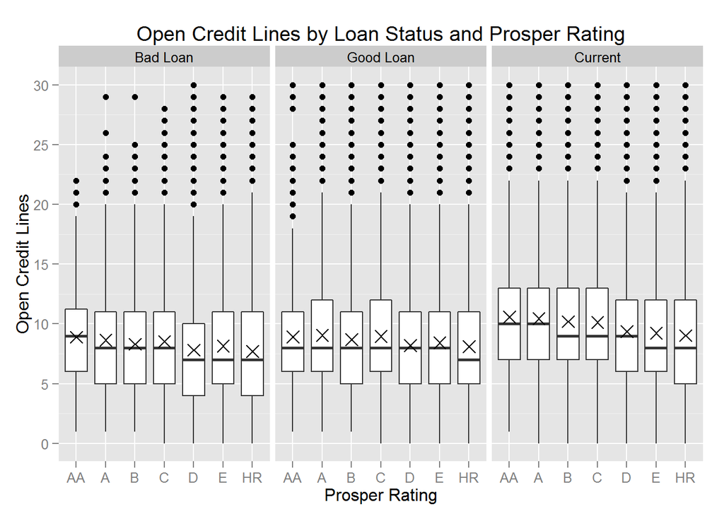

### 4.1.6 Stated Monthly Income, Loan Status and Prosper Rating

We could not tell the stated monthly Income has a relationship with the loan status or not.

[figure not shown]